# Modelli lineari e generalizzati - progetti di Gruppo

Rodolfo Metulini

2023-12-07

### Step di analisi:

1. Descrizione del problema e dei dati: descrivere qual è lo scopo dell’analisi e descrivere quante e quali variabili si hanno. (A questo punto dovreste aver definito l’obiettivo di analisi e scelto la/le variabili risposta)
2. EDA (Exploration Data Analysis): boxplot, correlation plot, barplot, tables.
3. Data Engineering (optional): create or add new variables.
4. Missing imputation (non richiesto per questo progetto) e outlier detection: spesso gli outlier vengono rimossi o tenuti da conto per l’analisi di un dataset.
5. Feature selection: decidere quali variabili entrano in gioco nell’analisi e perché, giustificare le proprie scelte o utilizzare modelli che aiutino a fare queste scelte.
6. Model selection: fare fitting di diversi modelli e confrontarli per scegliere il modello migliore per i vostri dati.
7. Conclusioni: concludere esplicitando a cosa è servito il modello finale e se avete risposto alla domanda di ricerca presentata al primo punto.
8. Bibliografia: è buona norma includere le fonti utilizzate per produrre il vostro report (paper di riferimento, ecc.).

### BASKETBALL TEAMS’ DATASET

```r
setwd("C:\\Users\\bnsda\\Desktop\\Progetti_R\\PROGETTO\\MATERIALE")
ds = read.delim("basketball_teams.txt")
head (ds)
```

```
##   year lgID tmID franchID confID divID rank confRank playoff
## 1 1946  NBA  BOS      BOS           ED    5        0
## 2 1946  NBA  CHS      CHS           WD    1        0       F
## 3 1946  NBA  CLR      CLR           WD    3        0      R1
## 4 1946  NBA  DTF      DTF           WD    4        0
## 5 1946  NBA  NYK      NYK           ED    3        0      SF
## 6 1946  NBA  PHW      GSW           ED    2        0      NC
##                    name o_fgm o_fga o_ftm o_fta o_3pm o_3pa o_oreb o_dreb o_reb
## 1        Boston Celtics  1397  5133   811  1375     0     0      0      0     0
## 2         Chicago Stags  1879  6309   939  1550     0     0      0      0     0
## 3      Cleveland Rebels  1674  5699   903  1428     0     0      0      0     0
## 4       Detroit Falcons  1437  5843   923  1494     0     0      0      0     0
## 5       New York Knicks  1465  5255   951  1438     0     0      0      0     0
## 6 Philadelphia Warriors  1510  5384  1098  1596     0     0      0      0     0
##   o_asts o_pf o_stl o_to o_blk o_pts d_fgm d_fga d_ftm d_fta d_3pm d_3pa d_oreb
```

[output cut: 34 more lines]

# Analisi delle variabili del dataset

year: stagione del torneo

lgID: nome della lega

franchID: nome squadra 3 cifre

confID: Conference di appartenenza della squadra

divID: Division di appartenenza della squadra

rank: classifica fine stagione regolare nella division

confRank: classifica fine stagione regolare nella conference

playoff: qualifica ai playoff (come da legenda)

name: nome squadra

o_: offensive

d_: defensive

fgm: tiri realizzati su azione

fga: tiri tentati su azione

ftm: tiri liberi realizzati

fta: tiri liberi tentati

3pm: tiri da 3 realizzati

3pa: tiri da 3 tentati

oreb: rimbalzi offensivi

dreb: rimbalzi difensivi

reb: rimbalzi totali (offensivi + difensivi)

asts: assists

pf: falli commessi

stl: palle recuperate

to: palle perse

blk: palle stoppate

tmRebound: rimbalzi di squadra

homeWon: vittore in casa

homeLost: sconfitte in casa

awayWon: vittorie in trasferta

awayLost: sconfitte in trasferta

neutWon: vittorie in campo neutro

neutLoss: sconfitte in campo neutro

confWon: vittorie contro squadre della stessa conference

confLoss: sconfitte contro squadre della stessa conference

divWon: vittorie con squadre stessa division

divLoss: sconfitte con squadre stessa division

won: vittorie totali

lost: sconfitte totali

games: partite giocate totali in stagione (won + lost)

min: minuti giocati in stagione

arena: nome stadio

attendance: numero spettatori

# progetto 1:

ABA league (1967-1975): VARIABILE DIPENDENTE: qualificazione ai playoff (SI/NO) e/o la vittoria di almeno la metà delle partite

COVARIATE: tutte le altre (o uno specifico insieme di queste, in base all’obiettivo di analisi)

attenzione che rimbalzi offensivi e difensivi, recuperi e stoppate, sono state rilevate solo a partire da un certo anno

# progetto 2:

NBA moderna (1976-2011): VARIABILE DIPENDENTE: qualificazione ai playoff (SI/NO)

COVARIATE: tutte le altre (o uno specifico insieme di queste, in base all’obiettivo di analisi)

# progetto 3:

NBA moderna (1976-2011): VARIABILE DIPENDENTE: qualificazione alle finali (SI/NO)

COVARIATE: tutte le altre (o uno specifico insieme di queste, in base all’obiettivo di analisi)

# progetto 4:

NBA moderna (1976-2011): VARIABILE DIPENDENTE: vittoria del titolo (SI/NO)

COVARIATE: tutte le altre (o uno specifico insieme di queste, in base all’obiettivo di analisi)

# progetto 5:

NBA moderna (1976-2011): VARIABILE DIPENDENTE: numero di vittorie in stagione

COVARIATE: tutte le altre (o uno specifico insieme di queste, in base all’obiettivo di analisi)

attenzione: qui considerare solo le squadre che hanno giocato 82 partite (dataset$games==82)

# progetto 6:

Confronto NBA moderna (1976-2011) e ABA (1967-1975): VARIABILE DIPENDENTE: qualificazione ai playoff (SI/NO)

COVARIATE: tutte le altre.

QUESITO: Le variabili che determinano la qualificazione ai playoff sono diverse nelle 2 leghe?

# Possibili quesiti di ricerca

1. Quanto è importante avere una buona precisione nel realizzare (da 2, da 3, ai liberi)?
2. Quanto è importante che gli avversari tirino male?
3. Qual’è l’effetto di prendere più rimbalzi degli avversari e di recuperare molti palloni (stl, blk)
4. è importante saper vincere anche fuori casa per qualificarsi ai playoff?
5. è importante vincere contro le squadre delle propria division per vincere il titolo?
6. l’effetto delle variabili esplicative è cambiato nel corso dsel tempo? (dummy temporale)
7. ci sono arene percui giocare li aiuta a vincere o a qualificarsi ai playoff?

# Analisi preliminari

```r
# trasformiamo characters in factors
ds$lgID <- as.factor(ds$lgID)
ds$franchID <- as.factor(ds$franchID)
```

# Analisi sulla variabile risposta

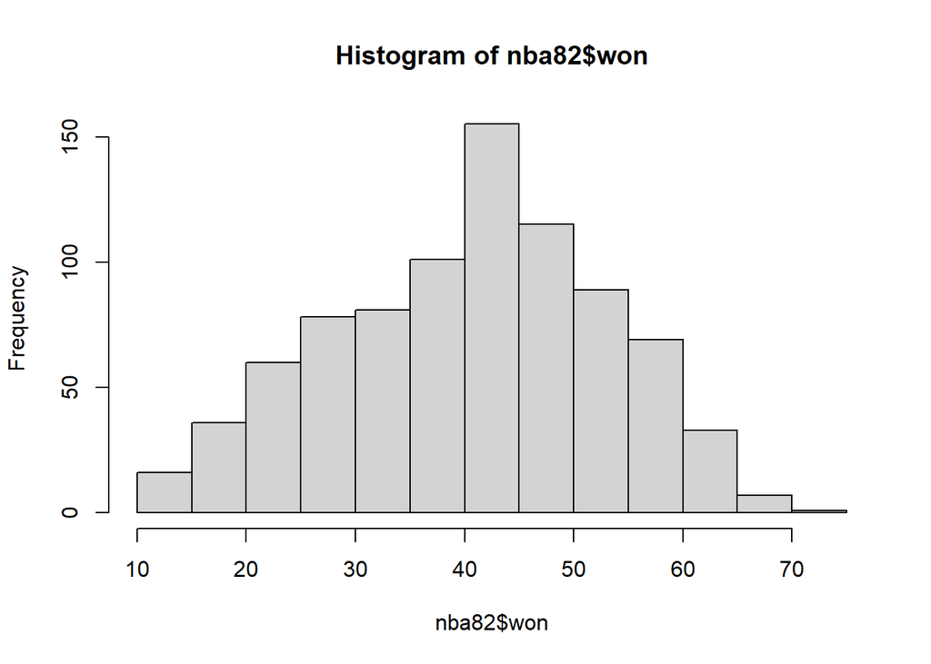

```r
# sUPPONIAMO la variabile risposta essere "won", per le stagione in cui le gare sono state 82
# e a partire dal 76 per la disponibilità di tutte le statistiche
nba82 = ds[ds$lgID=="NBA" & ds$games==82 & ds$year>=1976,]
# histogram
hist(nba82$won)
```

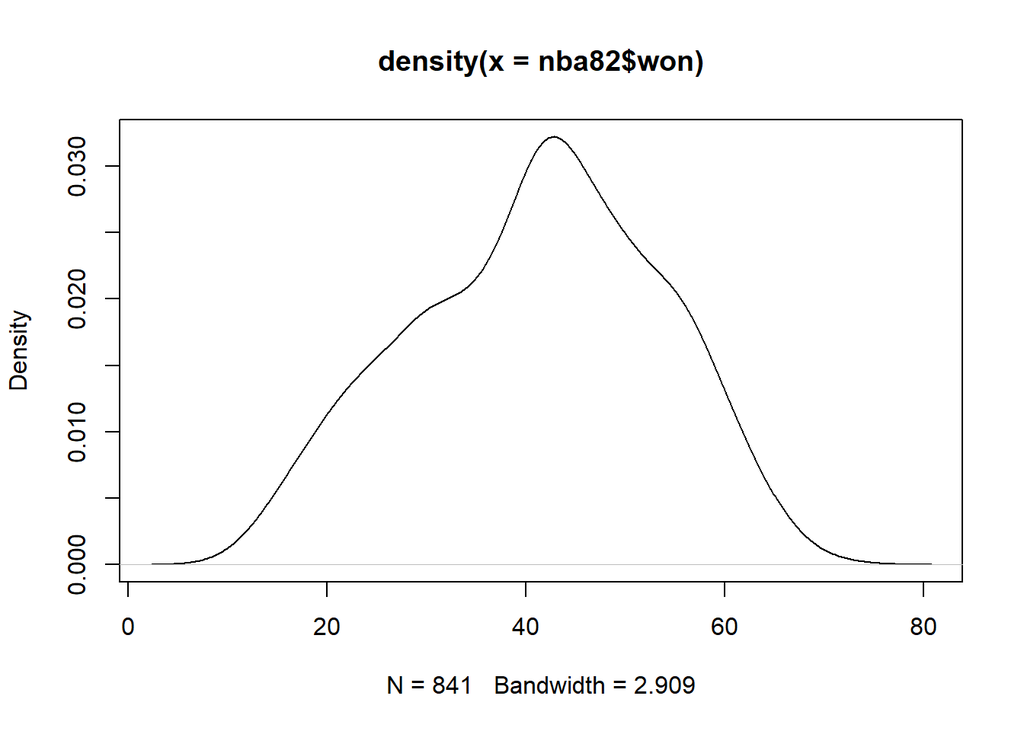

```r
#plot density
plot(density(nba82$won))
```

```r
# buon adattamento normale
```

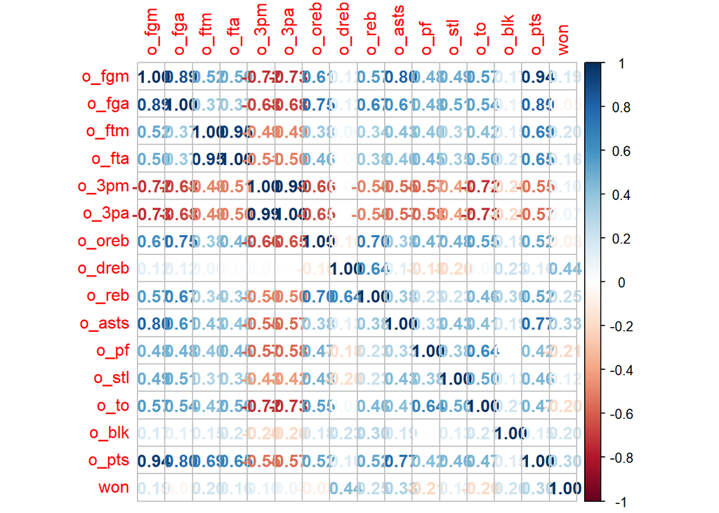

```r
library("corrplot")
M <- cor(as.matrix(nba82[,c(11:25,54)]))
         # correlation matrix
corrplot(M, method = 'number')
```

# Modello di regressione lineare

```r
# Supponiamo di voler stimare il modello con i Dean's 4 factors
# e controllando per la dummy "team"
nba82$o_df1 = (nba82$o_fgm + 0.5*nba82$o_3pm) / nba82$o_fga
nba82$d_df1 = (nba82$d_fgm + 0.5*nba82$d_3pm) / nba82$d_fga
nba82$o_df2 = nba82$o_to / (nba82$o_to + nba82$o_fga + 0.44*nba82$o_fta)
nba82$d_df2 = nba82$d_to / (nba82$d_to + nba82$d_fga + 0.44*nba82$d_fta)
nba82$o_df3 = nba82$o_oreb / (nba82$o_oreb + nba82$d_dreb)
nba82$d_df3 = nba82$d_oreb / (nba82$d_oreb + nba82$o_dreb)
nba82$o_df4 = nba82$o_ftm / nba82$o_fga
nba82$d_df4 = nba82$d_ftm / nba82$d_fga

(res1 = lm(won ~ o_df1 + d_df1 + o_df2 + d_df2 + o_df3 + d_df3 + o_df4 + d_df4, data= nba82))
```

```
##
## Call:
## lm(formula = won ~ o_df1 + d_df1 + o_df2 + d_df2 + o_df3 + d_df3 +
##     o_df4 + d_df4, data = nba82)
##
## Coefficients:
## (Intercept)        o_df1        d_df1        o_df2        d_df2        o_df3
##       16.36       363.11      -175.66      -395.43       309.64        74.88
##       d_df3        o_df4        d_df4
##     -213.90        87.91      -125.63
```

```r
# forse meglio normalizzarle per una più facile interpretazuione?
nba82$o_df1_z = scale(nba82$o_df1)
nba82$o_df2_z = scale(nba82$o_df2)
nba82$o_df3_z = scale(nba82$o_df3)
nba82$o_df4_z = scale(nba82$o_df4)
nba82$d_df1_z = scale(nba82$d_df1)
nba82$d_df2_z = scale(nba82$d_df2)
nba82$d_df3_z = scale(nba82$d_df3)
nba82$d_df4_z = scale(nba82$d_df4)

(res1 = lm(won ~ o_df1_z + d_df1_z + o_df2_z + d_df2_z + o_df3_z + d_df3_z + o_df4_z + d_df4_z, data= nba82))
```

```
##
## Call:
## lm(formula = won ~ o_df1_z + d_df1_z + o_df2_z + d_df2_z + o_df3_z +
##     d_df3_z + o_df4_z + d_df4_z, data = nba82)
##
## Coefficients:
## (Intercept)      o_df1_z      d_df1_z      o_df2_z      d_df2_z      o_df3_z
##      41.000        7.015       -5.510       -5.229        5.158        2.434
##     d_df3_z      o_df4_z      d_df4_z
##      -6.243        2.335       -3.723
```

# Multicollinearity

```r
library(car)
(vif(res1))
```

```
##  o_df1_z  d_df1_z  o_df2_z  d_df2_z  o_df3_z  d_df3_z  o_df4_z  d_df4_z
## 1.149619 1.482748 1.465608 1.881843 1.596367 1.561568 1.197212 1.396096
```

# variabili dummy

```r
# inseriamo al modello la variabile dummy "team"?
res_d = lm(won ~ tmID, data= nba82)
summary(res_d)
```

```
##
## Call:
## lm(formula = won ~ tmID, data = nba82)
##
## Residuals:
##     Min      1Q  Median      3Q     Max
## -31.406  -7.906   1.188   7.906  29.938
##
## Coefficients:
##             Estimate Std. Error t value Pr(>|t|)
## (Intercept)  40.1563     1.9996  20.082  < 2e-16 ***
## tmIDBOS       6.2500     2.8279   2.210 0.027377 *
## tmIDBUF     -11.6562     8.2446  -1.414 0.157808
## tmIDCHA     -11.3563     5.4395  -2.088 0.037138 *
## tmIDCHH      -0.4639     3.7203  -0.125 0.900788
## tmIDCHI       1.9062     2.8279   0.674 0.500447
## tmIDCLE      -1.0938     2.8279  -0.387 0.699026
## tmIDDAL       0.3080     2.9271   0.105 0.916216
## tmIDDEN      -1.0313     2.8279  -0.365 0.715452
## tmIDDET       4.0312     2.8279   1.426 0.154390
## tmIDGSW      -5.5000     2.8279  -1.945 0.052134 .
## tmIDHOU       3.8125     2.8279   1.348 0.177980
## tmIDIND      -0.3438     2.8279  -0.122 0.903280
## tmIDKCK      -1.2674     4.2679  -0.297 0.766581
## tmIDLAC     -11.3229     3.0545  -3.707 0.000224 ***
## tmIDLAL      13.5937     2.8279   4.807 1.83e-06 ***
## tmIDMEM      -7.2813     4.4713  -1.628 0.103821
## tmIDMIA      -1.1063     3.2243  -0.343 0.731613
## tmIDMIL       0.7500     2.8279   0.265 0.790911
## tmIDMIN      -6.0510     3.2761  -1.847 0.065112 .
## tmIDNJN      -4.2853     2.8506  -1.503 0.133156
## tmIDNOH       2.0437     5.4395   0.376 0.707223
## tmIDNOJ      -6.8229     6.8300  -0.999 0.318112
## tmIDNOK      -1.6563     8.2446  -0.201 0.840836
## tmIDNYK       0.1562     2.8279   0.055 0.955950
## tmIDNYN     -18.1562    11.4869  -1.581 0.114362
## tmIDOKC     -17.1563    11.4869  -1.494 0.135686
## tmIDORL       0.7911     3.2761   0.241 0.809242
## tmIDPHI       3.3125     2.8279   1.171 0.241796
## tmIDPHO       7.9375     2.8279   2.807 0.005124 **
## tmIDPOR       6.0312     2.8279   2.133 0.033246 *
## tmIDSAC      -3.5476     3.0922  -1.147 0.251611
## tmIDSAS       8.7813     2.8279   3.105 0.001968 **
## tmIDSDC      -9.1563     5.0322  -1.820 0.069206 .
## tmIDSEA       4.9405     2.8506   1.733 0.083452 .
## tmIDTOR      -6.3870     3.7203  -1.717 0.086403 .
## tmIDUTA       6.1541     2.9001   2.122 0.034141 *
## tmIDVAN     -21.5562     5.4395  -3.963 8.07e-05 ***
## tmIDWAS      -5.7017     3.9535  -1.442 0.149640
## tmIDWSB      -3.0610     3.1767  -0.964 0.335543
## ---
## Signif. codes:  0 '***' 0.001 '**' 0.01 '*' 0.05 '.' 0.1 ' ' 1
##
## Residual standard error: 11.31 on 801 degrees of freedom
## Multiple R-squared:  0.2104, Adjusted R-squared:  0.172
## F-statistic: 5.473 on 39 and 801 DF,  p-value: < 2.2e-16
```

```r
# la variabile team ha un effetto sulle vittorie?
# i.e. le vittorie medie per squadra sono uguali tra loro?
anova(res_d)
```

```
## Analysis of Variance Table
##
## Response: won
##            Df Sum Sq Mean Sq F value    Pr(>F)
## tmID       39  27312  700.31  5.4733 < 2.2e-16 ***
## Residuals 801 102488  127.95
## ---
## Signif. codes:  0 '***' 0.001 '**' 0.01 '*' 0.05 '.' 0.1 ' ' 1
```

```r
# si rifiuta l'ipotesi... posso inserire a modello la variabile

res2 = lm(won ~ o_df1_z + d_df1_z + o_df2_z + d_df2_z + o_df3_z + d_df3_z + o_df4_z + d_df4_z + tmID, data= nba82)
summary(res2)
```

```
##
## Call:
## lm(formula = won ~ o_df1_z + d_df1_z + o_df2_z + d_df2_z + o_df3_z +
##     d_df3_z + o_df4_z + d_df4_z + tmID, data = nba82)
##
## Residuals:
##      Min       1Q   Median       3Q      Max
## -12.8471  -3.2989   0.0626   3.2274  13.0776
##
## Coefficients:
##              Estimate Std. Error t value Pr(>|t|)
## (Intercept) 42.204253   0.897725  47.012  < 2e-16 ***
## o_df1_z      6.772865   0.210744  32.138  < 2e-16 ***
## d_df1_z     -5.545434   0.229387 -24.175  < 2e-16 ***
## o_df2_z     -5.241253   0.223365 -23.465  < 2e-16 ***
## d_df2_z      5.315168   0.250378  21.229  < 2e-16 ***
## o_df3_z      2.418835   0.236441  10.230  < 2e-16 ***
## d_df3_z     -6.368811   0.235329 -27.063  < 2e-16 ***
## o_df4_z      2.154120   0.207441  10.384  < 2e-16 ***
## d_df4_z     -3.754277   0.223828 -16.773  < 2e-16 ***
## tmIDBOS     -0.704525   1.280762  -0.550 0.582418
## tmIDBUF     -9.782977   3.687720  -2.653 0.008141 **
## tmIDCHA     -5.144214   2.436072  -2.112 0.035026 *
## tmIDCHH     -0.984175   1.664015  -0.591 0.554390
## tmIDCHI     -2.435962   1.272206  -1.915 0.055883 .
## tmIDCLE     -4.271502   1.263938  -3.380 0.000762 ***
## tmIDDAL     -1.352761   1.316244  -1.028 0.304384
## tmIDDEN     -1.694372   1.254654  -1.350 0.177251
## tmIDDET     -1.244624   1.260974  -0.987 0.323927
## tmIDGSW     -1.914937   1.261880  -1.518 0.129532
## tmIDHOU     -0.153438   1.291324  -0.119 0.905446
## tmIDIND     -1.670375   1.267390  -1.318 0.187896
## tmIDKCK     -5.743437   1.934733  -2.969 0.003082 **
## tmIDLAC     -0.951517   1.378535  -0.690 0.490246
## tmIDLAL      1.919242   1.303319   1.473 0.141261
## tmIDMEM     -3.525039   2.013121  -1.751 0.080327 .
## tmIDMIA     -0.367885   1.460969  -0.252 0.801254
## tmIDMIL     -0.814665   1.270238  -0.641 0.521482
## tmIDMIN     -0.331530   1.476647  -0.225 0.822414
## tmIDNJN     -2.406167   1.272662  -1.891 0.059035 .
```

[output cut: 10 more lines]

```
## tmIDSAC     -0.476020   1.390869  -0.342 0.732256
## tmIDSAS     -2.684343   1.289773  -2.081 0.037731 *
## tmIDSDC     -7.495612   2.253493  -3.326 0.000921 ***
## tmIDSEA      0.698722   1.273804   0.549 0.583481
## tmIDTOR     -2.658719   1.682178  -1.581 0.114386
## tmIDUTA      1.500711   1.320024   1.137 0.255931
## tmIDVAN     -1.932489   2.453243  -0.788 0.431091
## tmIDWAS     -2.678280   1.772739  -1.511 0.131234
## tmIDWSB     -2.758386   1.433072  -1.925 0.054611 .
## ---
## Signif. codes:  0 '***' 0.001 '**' 0.01 '*' 0.05 '.' 0.1 ' ' 1
##
## Residual standard error: 5.002 on 793 degrees of freedom
## Multiple R-squared:  0.8471, Adjusted R-squared:  0.8381
## F-statistic: 93.51 on 47 and 793 DF,  p-value: < 2.2e-16
```

# effetti interazione

```r
# più la squadra è forte a rimbalzo, maggiore è l'effetto della precisione dal campo sul numero di vittorie
res3 = lm(won ~ o_df1_z + d_df1_z + o_df2_z + d_df2_z + o_df3_z + d_df3_z + o_df4_z + d_df4_z + tmID + o_df1_z:o_df3_z, data= nba82)
summary(res3)
```

```
##
## Call:
## lm(formula = won ~ o_df1_z + d_df1_z + o_df2_z + d_df2_z + o_df3_z +
##     d_df3_z + o_df4_z + d_df4_z + tmID + o_df1_z:o_df3_z, data = nba82)
##
## Residuals:
##      Min       1Q   Median       3Q      Max
## -12.8910  -3.3312   0.0496   3.2688  13.0768
##
## Coefficients:
##                 Estimate Std. Error t value Pr(>|t|)
## (Intercept)     42.25732    0.89805  47.054  < 2e-16 ***
## o_df1_z          6.79588    0.21129  32.163  < 2e-16 ***
## d_df1_z         -5.52782    0.22962 -24.074  < 2e-16 ***
## o_df2_z         -5.25054    0.22334 -23.509  < 2e-16 ***
## d_df2_z          5.31730    0.25024  21.249  < 2e-16 ***
## o_df3_z          2.40087    0.23667  10.144  < 2e-16 ***
## d_df3_z         -6.38035    0.23535 -27.110  < 2e-16 ***
## o_df4_z          2.13631    0.20773  10.284  < 2e-16 ***
## d_df4_z         -3.76916    0.22397 -16.829  < 2e-16 ***
## tmIDBOS         -0.79149    1.28161  -0.618 0.537036
## tmIDBUF         -9.82389    3.68578  -2.665 0.007848 **
## tmIDCHA         -5.32651    2.43833  -2.184 0.029218 *
## tmIDCHH         -1.04482    1.66367  -0.628 0.530172
## tmIDCHI         -2.62449    1.27888  -2.052 0.040481 *
## tmIDCLE         -4.26237    1.26325  -3.374 0.000777 ***
## tmIDDAL         -1.32971    1.31562  -1.011 0.312462
## tmIDDEN         -1.67370    1.25404  -1.335 0.182377
## tmIDDET         -1.25623    1.26030  -0.997 0.319178
## tmIDGSW         -1.86626    1.26167  -1.479 0.139486
## tmIDHOU         -0.17027    1.29066  -0.132 0.895075
## tmIDIND         -1.68959    1.26676  -1.334 0.182657
## tmIDKCK         -5.78680    1.93391  -2.992 0.002855 **
## tmIDLAC         -1.05043    1.37965  -0.761 0.446660
## tmIDLAL          1.74110    1.30903   1.330 0.183880
## tmIDMEM         -3.56479    2.01220  -1.772 0.076848 .
## tmIDMIA         -0.38916    1.46023  -0.267 0.789919
## tmIDMIL         -0.87335    1.27025  -0.688 0.491940
## tmIDMIN         -0.37967    1.47624  -0.257 0.797103
## tmIDNJN         -2.33835    1.27291  -1.837 0.066582 .
```

[output cut: 11 more lines]

```
## tmIDSAS         -2.67033    1.28909  -2.071 0.038637 *
## tmIDSDC         -7.52905    2.25237  -3.343 0.000869 ***
## tmIDSEA          0.66846    1.27328   0.525 0.599735
## tmIDTOR         -2.71130    1.68167  -1.612 0.107303
## tmIDUTA          1.52989    1.31946   1.159 0.246609
## tmIDVAN         -2.18274    2.45863  -0.888 0.374926
## tmIDWAS         -2.80181    1.77403  -1.579 0.114655
## tmIDWSB         -2.72593    1.43247  -1.903 0.057408 .
## o_df1_z:o_df3_z  0.24173    0.17599   1.374 0.169977
## ---
## Signif. codes:  0 '***' 0.001 '**' 0.01 '*' 0.05 '.' 0.1 ' ' 1
##
## Residual standard error: 4.999 on 792 degrees of freedom
## Multiple R-squared:  0.8475, Adjusted R-squared:  0.8383
## F-statistic:  91.7 on 48 and 792 DF,  p-value: < 2.2e-16
```

```r
# non è significativo...
```

# test F, significatività singoli coefficienti, R^2

```r
summary(res2)
```

```
##
## Call:
## lm(formula = won ~ o_df1_z + d_df1_z + o_df2_z + d_df2_z + o_df3_z +
##     d_df3_z + o_df4_z + d_df4_z + tmID, data = nba82)
##
## Residuals:
##      Min       1Q   Median       3Q      Max
## -12.8471  -3.2989   0.0626   3.2274  13.0776
##
## Coefficients:
##              Estimate Std. Error t value Pr(>|t|)
## (Intercept) 42.204253   0.897725  47.012  < 2e-16 ***
## o_df1_z      6.772865   0.210744  32.138  < 2e-16 ***
## d_df1_z     -5.545434   0.229387 -24.175  < 2e-16 ***
## o_df2_z     -5.241253   0.223365 -23.465  < 2e-16 ***
## d_df2_z      5.315168   0.250378  21.229  < 2e-16 ***
## o_df3_z      2.418835   0.236441  10.230  < 2e-16 ***
## d_df3_z     -6.368811   0.235329 -27.063  < 2e-16 ***
## o_df4_z      2.154120   0.207441  10.384  < 2e-16 ***
## d_df4_z     -3.754277   0.223828 -16.773  < 2e-16 ***
## tmIDBOS     -0.704525   1.280762  -0.550 0.582418
## tmIDBUF     -9.782977   3.687720  -2.653 0.008141 **
## tmIDCHA     -5.144214   2.436072  -2.112 0.035026 *
## tmIDCHH     -0.984175   1.664015  -0.591 0.554390
## tmIDCHI     -2.435962   1.272206  -1.915 0.055883 .
## tmIDCLE     -4.271502   1.263938  -3.380 0.000762 ***
## tmIDDAL     -1.352761   1.316244  -1.028 0.304384
## tmIDDEN     -1.694372   1.254654  -1.350 0.177251
## tmIDDET     -1.244624   1.260974  -0.987 0.323927
## tmIDGSW     -1.914937   1.261880  -1.518 0.129532
## tmIDHOU     -0.153438   1.291324  -0.119 0.905446
## tmIDIND     -1.670375   1.267390  -1.318 0.187896
## tmIDKCK     -5.743437   1.934733  -2.969 0.003082 **
## tmIDLAC     -0.951517   1.378535  -0.690 0.490246
## tmIDLAL      1.919242   1.303319   1.473 0.141261
## tmIDMEM     -3.525039   2.013121  -1.751 0.080327 .
## tmIDMIA     -0.367885   1.460969  -0.252 0.801254
## tmIDMIL     -0.814665   1.270238  -0.641 0.521482
## tmIDMIN     -0.331530   1.476647  -0.225 0.822414
## tmIDNJN     -2.406167   1.272662  -1.891 0.059035 .
```

[output cut: 10 more lines]

```
## tmIDSAC     -0.476020   1.390869  -0.342 0.732256
## tmIDSAS     -2.684343   1.289773  -2.081 0.037731 *
## tmIDSDC     -7.495612   2.253493  -3.326 0.000921 ***
## tmIDSEA      0.698722   1.273804   0.549 0.583481
## tmIDTOR     -2.658719   1.682178  -1.581 0.114386
## tmIDUTA      1.500711   1.320024   1.137 0.255931
## tmIDVAN     -1.932489   2.453243  -0.788 0.431091
## tmIDWAS     -2.678280   1.772739  -1.511 0.131234
## tmIDWSB     -2.758386   1.433072  -1.925 0.054611 .
## ---
## Signif. codes:  0 '***' 0.001 '**' 0.01 '*' 0.05 '.' 0.1 ' ' 1
##
## Residual standard error: 5.002 on 793 degrees of freedom
## Multiple R-squared:  0.8471, Adjusted R-squared:  0.8381
## F-statistic: 93.51 on 47 and 793 DF,  p-value: < 2.2e-16
```

```r
# poi vedremo come scegliere tra le variabili
```

# Analisi dei residui e diagnostica

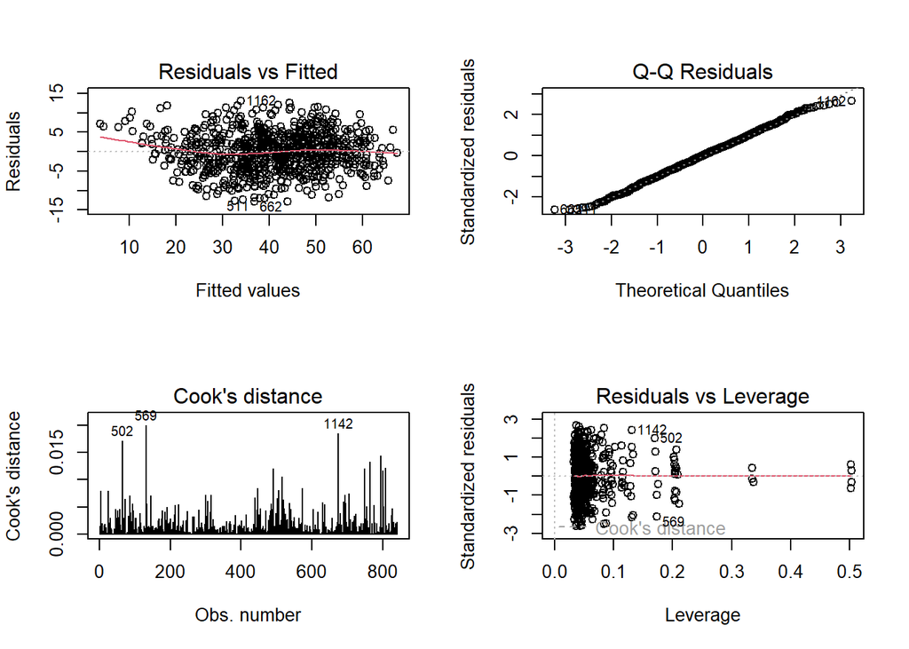

```r
par(mfrow = c(2, 2))
plot(res2,  which = c(1:2,4:5))
```

```r
# questi possono portare ad utilizzare altri modelli
```

# Può aiutare l’uso della Gamma?

```r
# si direbbe di no, e che quindi i coefficienti stimati saranno simili
# vediamo
res_gamma = glm(won ~ o_df1_z + d_df1_z + o_df2_z + d_df2_z + o_df3_z + d_df3_z + o_df4_z + d_df4_z + tmID, family = Gamma(link=identity), data= nba82)

summary(res_gamma)
```

```
##
## Call:
## glm(formula = won ~ o_df1_z + d_df1_z + o_df2_z + d_df2_z + o_df3_z +
##     d_df3_z + o_df4_z + d_df4_z + tmID, family = Gamma(link = identity),
##     data = nba82)
##
## Coefficients:
##             Estimate Std. Error t value Pr(>|t|)
## (Intercept) 41.36639    0.92672  44.637  < 2e-16 ***
## o_df1_z      6.34361    0.21025  30.172  < 2e-16 ***
## d_df1_z     -5.23626    0.22635 -23.134  < 2e-16 ***
## o_df2_z     -4.48493    0.22283 -20.127  < 2e-16 ***
## d_df2_z      4.69722    0.24918  18.851  < 2e-16 ***
## o_df3_z      2.12453    0.24198   8.780  < 2e-16 ***
## d_df3_z     -5.85412    0.22605 -25.897  < 2e-16 ***
## o_df4_z      2.19989    0.20649  10.654  < 2e-16 ***
## d_df4_z     -3.27304    0.20667 -15.837  < 2e-16 ***
## tmIDBOS     -0.64596    1.40210  -0.461 0.645134
## tmIDBUF     -9.40684    3.07666  -3.057 0.002307 **
## tmIDCHA     -5.27078    2.01381  -2.617 0.009031 **
## tmIDCHH     -1.60259    1.68868  -0.949 0.342900
## tmIDCHI     -0.45531    1.26708  -0.359 0.719440
## tmIDCLE     -3.46014    1.26560  -2.734 0.006396 **
## tmIDDAL      0.65659    1.23136   0.533 0.594027
## tmIDDEN      0.26576    1.20357   0.221 0.825301
## tmIDDET     -0.10825    1.35640  -0.080 0.936412
## tmIDGSW     -0.41894    1.21137  -0.346 0.729557
## tmIDHOU     -0.11250    1.38799  -0.081 0.935424
## tmIDIND     -1.86011    1.34218  -1.386 0.166171
## tmIDKCK     -5.30274    2.06198  -2.572 0.010302 *
## tmIDLAC     -1.66476    1.19158  -1.397 0.162774
## tmIDLAL      4.08007    1.62123   2.517 0.012044 *
## tmIDMEM     -3.17647    1.79758  -1.767 0.077600 .
## tmIDMIA     -1.06915    1.37067  -0.780 0.435613
## tmIDMIL     -0.63306    1.33810  -0.473 0.636267
## tmIDMIN      0.16725    1.33702   0.125 0.900481
## tmIDNJN     -2.11769    1.25303  -1.690 0.091411 .
## tmIDNOH      0.58586    2.30876   0.254 0.799751
## tmIDNOJ     -3.11108    2.85117  -1.091 0.275534
## tmIDNOK      0.88888    4.00834   0.222 0.824561
```

[output cut: 11 more lines]

```
## tmIDTOR      0.29588    1.49244   0.198 0.842896
## tmIDUTA      1.54733    1.48886   1.039 0.298996
## tmIDVAN      0.07362    1.52295   0.048 0.961455
## tmIDWAS     -2.89724    1.64915  -1.757 0.079336 .
## tmIDWSB     -2.09027    1.43559  -1.456 0.145777
## ---
## Signif. codes:  0 '***' 0.001 '**' 0.01 '*' 0.05 '.' 0.1 ' ' 1
##
## (Dispersion parameter for Gamma family taken to be 0.0203061)
##
##     Null deviance: 91.562  on 840  degrees of freedom
## Residual deviance: 16.987  on 793  degrees of freedom
## AIC: 5360.4
##
## Number of Fisher Scoring iterations: 10
```

```r
# vedere il parametro di dispersione
# dispersione = 1/alpha = 0.0203
(alpha = 1 / 0.0203061)
```

```
## [1] 49.24629
```

```r
# per alpha grande la distribuzione tende ad essere simmetrica e non dispersa (quindi con sigma che non dipende da mu)
```

# Serve?

```r
# funzione link logaritmo su E(Y): f(E(Y)) = log(E(Y))
res_pois = glm(won ~ o_df1_z + d_df1_z + o_df2_z + d_df2_z + o_df3_z + d_df3_z + o_df4_z + d_df4_z + tmID, family=poisson(link=log), data=nba82)

normal = coefficients(res2)
gamma = coefficients(res_gamma)
poisson = exp(coefficients(res_pois))

cbind(normal, gamma, poisson)
```

```
##                   normal       gamma    poisson
## (Intercept) 42.204252704 41.36639005 41.1140788
## o_df1_z      6.772865389  6.34361006  1.1869174
## d_df1_z     -5.545433643 -5.23625986  0.8633502
## o_df2_z     -5.241252771 -4.48492980  0.8710278
## d_df2_z      5.315167737  4.69722258  1.1527181
## o_df3_z      2.418834560  2.12453141  1.0627997
## d_df3_z     -6.368811324 -5.85411878  0.8464256
## o_df4_z      2.154119897  2.19989297  1.0626463
## d_df4_z     -3.754276764 -3.27304204  0.9039345
## tmIDBOS     -0.704524957 -0.64595765  0.9542013
## tmIDBUF     -9.782977447 -9.40683774  0.7549669
## tmIDCHA     -5.144213509 -5.27077901  0.8659039
## tmIDCHH     -0.984175246 -1.60258723  0.9801062
## tmIDCHI     -2.435961832 -0.45530642  0.9032792
## tmIDCLE     -4.271502301 -3.46014161  0.8852171
## tmIDDAL     -1.352761486  0.65659264  0.9303603
## tmIDDEN     -1.694371595  0.26575540  0.9446201
## tmIDDET     -1.244624478 -0.10824774  0.9545497
## tmIDGSW     -1.914936792 -0.41893642  0.9498490
## tmIDHOU     -0.153437950 -0.11249509  1.0006581
## tmIDIND     -1.670375300 -1.86010758  0.9753508
## tmIDKCK     -5.743437434 -5.30274163  0.8794129
## tmIDLAC     -0.951517447 -1.66476228  0.9450469
## tmIDLAL      1.919242273  4.08007028  0.9950298
## tmIDMEM     -3.525039345 -3.17646956  0.9118021
## tmIDMIA     -0.367885109 -1.06914776  0.9758310
## tmIDMIL     -0.814664985 -0.63306305  0.9838219
## tmIDMIN     -0.331530299  0.16725296  0.9746793
## tmIDNJN     -2.406166511 -2.11768706  0.9401548
## tmIDNOH     -0.377704061  0.58586082  0.9503848
## tmIDNOJ     -2.861951306 -3.11107755  0.9308066
## tmIDNOK     -0.246498257  0.88887553  1.0212505
## tmIDNYK     -0.006190687 -0.23612243  1.0066471
## tmIDNYN     -8.491662197 -8.76523762  0.7090274
## tmIDOKC     -7.851872021 -7.85020101  0.7513163
## tmIDORL     -0.451237699 -0.16858923  0.9772902
## tmIDPHI      1.307455192  1.56503518  1.0127140
## tmIDPHO     -1.411531549 -0.54990889  0.9489403
## tmIDPOR     -1.957849217  0.28808809  0.9353938
## tmIDSAC     -0.476019597 -0.53269285  0.9783461
## tmIDSAS     -2.684343023 -1.12157835  0.8980327
## tmIDSDC     -7.495612133 -7.47984586  0.8320832
## tmIDSEA      0.698721537  0.99263523  1.0156145
## tmIDTOR     -2.658718541  0.29588337  0.9092692
## tmIDUTA      1.500710726  1.54732609  1.0218017
## tmIDVAN     -1.932489246  0.07362494  0.7798429
## tmIDWAS     -2.678280417 -2.89724174  0.9375774
## tmIDWSB     -2.758385893 -2.09027289  0.9347126
```

```r
# i coefficienti risultano simili con uso normale e uso gamma.
# i coefficienti della Poisson hanno diversa interpretazione
# es. un aumento unitario in o_df1_z aumenta il numero di vittorie di 1.1869, cioè del 18.69%
# es. un aumento unitario in d_df1_z diminuisce il numero di vittorie di 0.8634, quindi del 13.66%
```